# Wrangling practice

Author

Sepehr Akbari

Published

October 4, 2024

## Setup

Loading required libraries and the `astronauts` and `trash_wheel` dataset.

```r
library(tidyverse)
library(readxl)
library(gt)

astronauts <- read_excel(file.path(base_dir, "Data/astronauts.xlsx"))
trashwheel <- read_csv(file.path(base_dir, "Data/trash_wheel.csv"))
```

## Problem 1

```r
topEVA <- astronauts %>%
  slice_max(order_by = eva_hrs_mission, n = 5)

topEVA %>%
  select(name, eva_hrs_mission) %>%
  gt::gt()
```

| name | eva_hrs_mission |
| --- | --- |
| Solovyev, Anatoly | 89.13 |
| Morgan, Andrew | 39.52 |
| Whitson, Peggy A. | 35.35 |
| Tani, Daniel M. | 34.98 |
| Walheim, Rex J. | 34.60 |

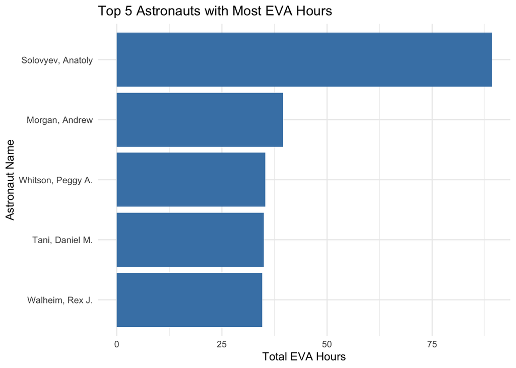

```r
topEVA %>%
  ggplot(
    aes(
      x = eva_hrs_mission,
      y = reorder(name, eva_hrs_mission)
      # I'm using reorder() to arrange names based on the EVA hours
    )
  ) +
  geom_col(fill = "steelblue") +
  labs(
    title = "Top 5 Astronauts with Most EVA Hours",
    x = "Total EVA Hours",
    y = "Astronaut Name"
  ) +
  theme_minimal()
```

## Problem 2

```r
current_year <- 2024
my_astronauts <- astronauts %>%
  mutate(age = current_year - year_of_birth)

top_occupations <- my_astronauts %>%
  mutate(occupation = tolower(occupation)) %>%
  group_by(occupation) %>%
  summarise(
    total_count = n(),
    min_age = min(age, na.rm = TRUE),
    median_age = median(age, na.rm = TRUE),
    max_age = max(age, na.rm = TRUE)
  ) %>%
  slice_max(order_by = total_count, n = 5)

gt::gt(top_occupations)
```

| occupation | total_count | min_age | median_age | max_age |
| --- | --- | --- | --- | --- |
| msp | 498 | 49 | 70 | 98 |
| commander | 315 | 47 | 75 | 103 |
| pilot | 197 | 52 | 73 | 103 |
| flight engineer | 196 | 44 | 66 | 98 |
| psp | 59 | 64 | 76 | 103 |

## Problem 3

```r
EVA_status <- my_astronauts %>%
  group_by(year_of_mission, military_civilian) %>%
  summarise(total_eva = sum(eva_hrs_mission)) %>%
  ungroup()

EVA_status %>%
  slice_head(n = 10) %>%
  gt::gt()
```

| year_of_mission | military_civilian | total_eva |
| --- | --- | --- |
| 1961 | military | 0.00 |
| 1962 | military | 0.00 |
| 1963 | military | 0.00 |
| 1964 | civilian | 0.00 |
| 1964 | military | 0.00 |
| 1965 | military | 1.06 |
| 1966 | civilian | 1.47 |
| 1966 | military | 7.62 |
| 1967 | military | 0.00 |
| 1968 | civilian | 0.00 |

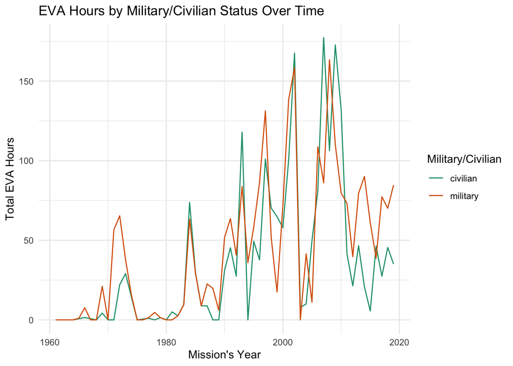

```r
ggplot(
  EVA_status,
  aes(
    x = year_of_mission,
    y = total_eva,
    color = military_civilian
  )
) +
  geom_line() +
  labs(
    title = "EVA Hours by Military/Civilian Status Over Time",
    x = "Mission's Year",
    y = "Total EVA Hours",
    color = "Military/Civilian"
  ) +
  theme_minimal() +
  scale_color_brewer(palette = "Dark2")
```

Looking at the plot, we can see that in the early years of space exploration, military astronauts generally logged more EVA hours than their civilian counterparts. This trend continued through the 1960s and into the early 1980s, with military astronauts clearly contributing the majority of EVA hours. However, starting in the mid-1980s, the gap between military and civilian EVA hours began to close. By the 2000s, civilian astronauts were performing EVA activities at a rate nearly equal to or sometimes exceeding that of military astronauts. In the past decade however, this trend has shifted again, with military astronauts once again logging significantly more EVA hours than civilians.

## Problem 4

I am not exactly sure of my topic for mister trash wheel yet, but I found the idea to assess anti-smoking campaigns, and their affect specificaly in Baltimore, to be interesting. Of course the data shown here, is not creating any conclusions, however it is one of the aspects of my research.

```r
cigaretteButtsCollected <- trashwheel %>%
  group_by(Year) %>%
  summarise(total_cigarette_butts = sum(CigaretteButts, na.rm = TRUE))

cigaretteButtsCollected %>%
  gt::gt()
```

| Year | total_cigarette_butts |
| --- | --- |
| 2014 | 4162000 |
| 2015 | 2856000 |
| 2016 | 1919600 |
| 2017 | 997620 |
| 2018 | 1293680 |
| 2019 | 485498 |
| 2020 | 460500 |
| 2021 | 439800 |
| 2022 | 507510 |
| 2023 | 496090 |

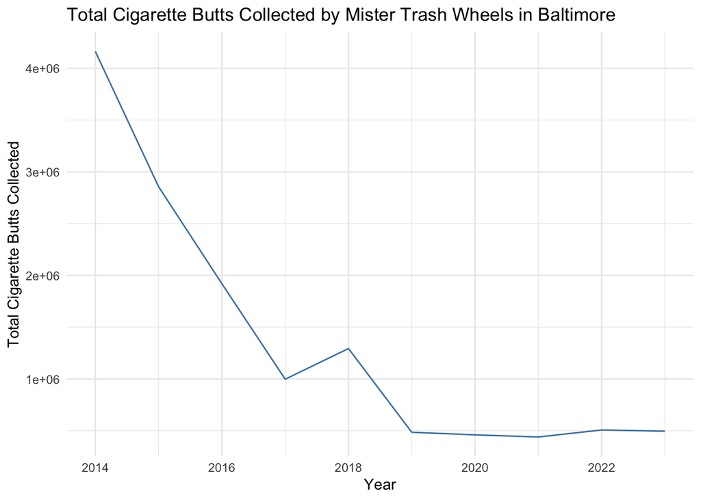

```r
ggplot(
  cigaretteButtsCollected,
  aes(
    x = Year,
    y = total_cigarette_butts
  )
) +
  geom_line(color = "steelblue") +
  labs(
    title = "Total Cigarette Butts Collected by Mister Trash Wheels in Baltimore",
    x = "Year",
    y = "Total Cigarette Butts Collected"
  ) +
  theme_minimal()
```